# UNICEF Global Inequality in Adolescent Population

# 1 Introduction

Adolescent population distribution differs significantly across countries due to variations in demographic structure, economic development, and fertility rates. Regions with higher proportions of adolescents often face unique challenges related to education, healthcare, and employment, while countries with lower proportions typically reflect aging populations.

This report examines global inequality in adolescent population using UNICEF data. Through data cleaning, visualization, and analysis, it highlights key trends, identifies high-concentration regions, and provides insights into global demographic differences. The analysis is based on the selected dataset relevant to adolescent population indicators.

# 2 Data Cleaning

The dataset was filtered by choosing the variables that were of interest to the study, including country, year, and the value of adolescent population. Incomplete values were eliminated to achieve accuracy and consistency of data. This measure enhances the validity of the analysis and warranted visualizations.

# 3 Time Series Analysis

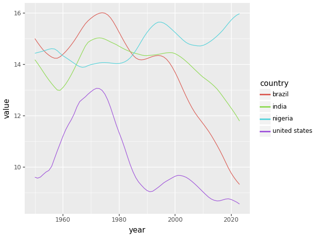

# 4 Top Countries

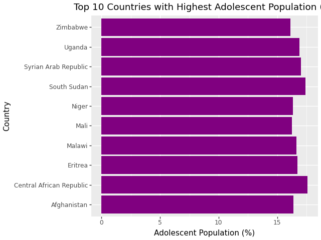

The bar chart presents the top 10 countries with the highest adolescent population percentages. Most of these countries are located in Sub-Saharan Africa, indicating a concentration of younger populations in this region. High adolescent proportions are often associated with higher fertility rates and lower levels of economic development. This distribution reflects regional demographic patterns and highlights areas where youth-focused policies and resources are particularly important.

# 5 Relationship Analysis

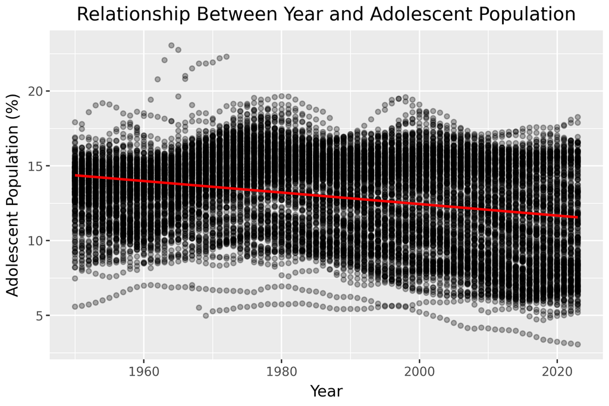

The scatter plot illustrates the relationship between time (year) and adolescent population percentage. The data points show a wide dispersion, indicating variation across countries and time periods. The regression line suggests a slight downward trend, reflecting a gradual decline in adolescent population percentages globally. This highlights differences in demographic transitions rather than a strong linear relationship.

# 6 Global Distribution

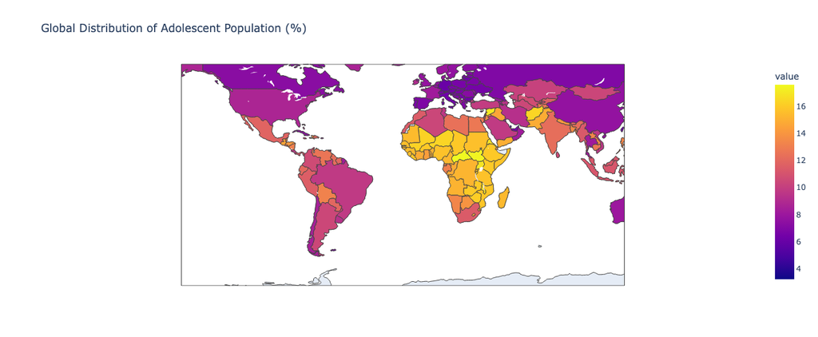

The choropleth map shows that there is an unequal distribution of adolescent population in the world with high percentages in Sub-Saharan Africa and low percentages in developed world like Europe and North America. The analysis indicates that worldwide adolescent population is not equally distributed. Developing regions, especially Africa, stay at the top list for having the largest proportion of adolescents. On the other hand, developed regions register the lowest figures as a result of aging populations. Such discrepancies call for geographically-targeted policies relying on education, health, and employment for the youth. In fact, this can be a deciding factor in sustainable development and global equity.

# 7 Conclusion

The analysis indicates that worldwide adolescent population is not equally distributed. Developing regions, especially Africa, stay at the top list for having the largest proportion of adolescents. On the other hand, developed regions register the lowest figures as a result of aging populations. Such discrepancies call for geographically-targeted policies relying on education, health, and employment for the youth. In fact, this can be a deciding factor in sustainable development and global equity. These findings suggest that countries with higher adolescent populations may face increased pressure on education systems and employment markets, while aging populations in developed countries may present challenges related to workforce sustainability.